# Home Work - 9

## Question 9:

We will use the codes that we’ve discussed to find the compressed version of the picture. We see that with aproxamitly 115 components we can get 99% of the original picture. Therefore we need `115` components.

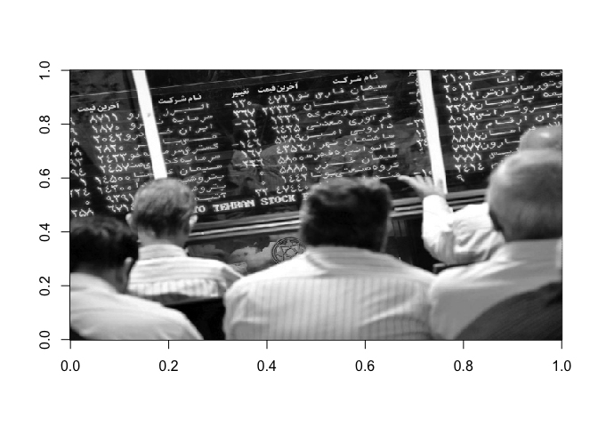

```r
#-----------------------------------------------
pic = flip(readImage("/Users/shervin/Desktop/Data Analysis/HW9'/Unknown.jpg"))

red.weigth   = .2989; green.weigth = .587; blue.weigth  = 0.114

img = red.weigth * imageData(pic)[,,1] +
  green.weigth * imageData(pic)[,,2] + blue.weigth  * imageData(pic)[,,3]
image(img, col = grey(seq(0, 1, length = 256)))
```

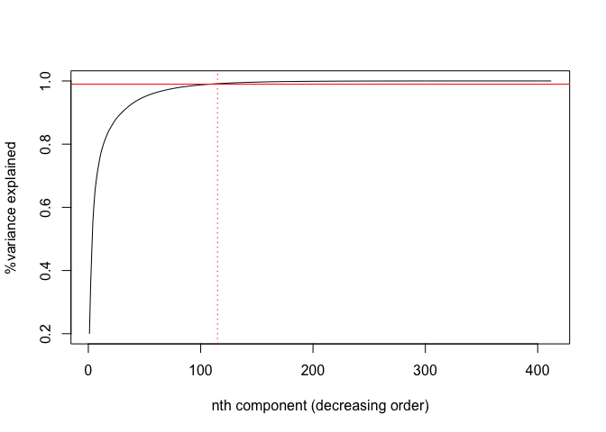

```r
#-----------------------------------------------
#PCA
pca.img = prcomp(img, scale=TRUE)

plot(summary(pca.img)$importance[3,], type="l",
     ylab="%variance explained", xlab="nth component (decreasing order)")

#-----------------------------------------------
#With trial and error 115 is the best number:
abline(h=0.99,col="red");abline(v = 115,col="red",lty=3)
```

```r
size = c()
n = 200
for (i in 1:n){
  chosen.components = 1:i
  feature.vector = pca.img$rotation[,chosen.components]
  compact.data = t(feature.vector) %*% t(img)

  temp = (object.size(compact.data) + object.size(feature.vector))/1000000
  size = c(size,temp)
  approx.img = t(feature.vector %*% compact.data)
}
temp1 = data.frame(PC = 1:n,size = size)

check = data.frame(P = 1:n,value = size)

check %>% hchart(hcaes(x = P , y = value), type = "line") %>%
  hc_title(text = "Size - number of PCs") %>%
  hc_yAxis(title = list(text = "Mean Value")) %>%
  hc_xAxis(text = "PCs")
```

[interactive chart not shown]

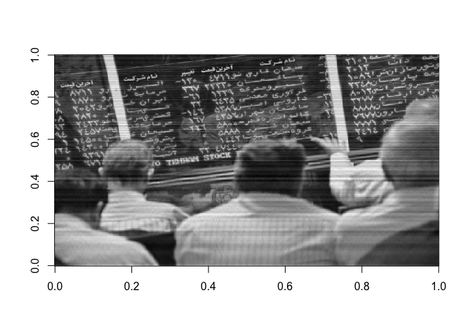

```r
#-----------------------------------------------
#PCA Picture:
chosen.components = 1:115
feature.vector = pca.img$rotation[,chosen.components]
compact.data = t(feature.vector) %*% t(img)
temp = (object.size(compact.data) + object.size(feature.vector))/1000000
approx.img = t(feature.vector %*% compact.data)
image(approx.img, col = grey(seq(0, 1, length = 256)))
```

```r
#-----------------------------------------------
```

## Question 10:

There are several ideas we can choose to put:  
1. We could see where the biggest difference between the highest and lowest in a day happend.  
2. If we knew which companies went bankrupt through these years, we could use that data to predict which companies will go bankrupt in the future.  
3. We could also use the data with the GDP data to see how it influences the GDP of America  
4. When is the least riskiest time to but a stock? we could find the answers by checking the oscilations of the stock market.  
5. How have the smallest stocks change through time? using the data we have, we can see the change of every stock in time.